# VCF QC and Screening

Zack Guo

UCL  
wegmzgu@ucl.ac.uk

September 11, 2026

# Library packages

```r
# Load Bioconductor and plotting packages used for VCF parsing and QC.
library(VariantAnnotation)
library(GenomicRanges)
library(dplyr)
library(ggplot2)
```

# Aim

This notebook applies a consistent quality screen to the raw Mutect2 VCFs and writes the retained biallelic SNVs and per-sample QC metrics for downstream analysis.

# Input and screening rule

The eight `Com01-04` H/I files are tumour VCFs with a matched normal column in each file. The thresholds are written to disk so the filtering policy is recorded alongside the output tables.

```r
project_dir <- "C:/Bioinfo data/cell of origin"
out_dir <- file.path(project_dir, "practice_results")
# Keep the output directory stable so notebook 05 can consume these tables.
dir.create(out_dir, showWarnings = FALSE)

# Discover the eight labelled tumour VCFs.
vcfs <- list.files(
  "C:/Bioinfo data/Mutation files",
  pattern = "^Com0[1-4][HI]\\.vcf$",
  full.names = TRUE
)
vcfs <- sort(vcfs)
stopifnot(length(vcfs) == 8)

# Define the depth, allele-support, and TLOD thresholds used for all samples.
rule <- c(tumor_dp = 30, tumor_alt = 5, tumor_af = 0.08,
          normal_dp = 15, normal_alt = 1, normal_af = 0.01, tlod = 6.3)
write.table(data.frame(parameter = names(rule), value = rule),
            file.path(out_dir, "screening_rule.tsv"), sep = "\t",
            row.names = FALSE, quote = FALSE)
```

# Read and screen one tumour-normal VCF

`screen_vcf()` keeps standard biallelic SNVs, extracts the tumour and matched- normal evidence, and applies all screening thresholds together. The function returns both per-sample QC counts and the retained SNV rows.

```r
screen_vcf <- function(path) {
  # Derive the output sample name from the VCF filename.
  sample_id <- sub("\\.vcf$", "", basename(path), ignore.case = TRUE)
  # Read only the INFO/FORMAT fields needed for the quality screen.
  param <- ScanVcfParam(info = "TLOD", geno = c("AD", "AF", "DP"))
  vcf <- readVcf(path, genome = NA_character_, param = param)

  sample_names <- colnames(vcf)
  # Each file contains one tumour column and one matched-normal column.
  normal <- grep("N(WES)?$", sample_names, ignore.case = TRUE)
  tumor <- setdiff(seq_along(sample_names), normal)
  stopifnot(length(normal) == 1, length(tumor) == 1)

  # Restrict the candidate set to standard biallelic single-nucleotide variants.
  snv <- isSNV(vcf, singleAltOnly = TRUE)
  x <- vcf[snv]
  geno_data <- geno(x)
  ad <- geno_data$AD

  get_ad <- function(sample, allele) {
    vapply(ad[, sample], function(z)
      if (length(z) >= allele) z[[allele]] else NA_integer_, integer(1))
  }

  tumor_alt <- get_ad(tumor, 2)
  normal_alt <- get_ad(normal, 2)
  tumor_dp <- geno_data$DP[, tumor]
  normal_dp <- geno_data$DP[, normal]
  tumor_af <- as.numeric(geno_data$AF[, tumor])
  normal_af <- as.numeric(geno_data$AF[, normal])
  tlod <- vapply(info(x)[["TLOD"]], function(z)
    if (length(z)) z[[1]] else NA_real_, numeric(1))

  # Require tumour evidence and reject sites with meaningful normal support.
  keep <- tumor_dp >= rule["tumor_dp"] &
    tumor_alt >= rule["tumor_alt"] & tumor_af >= rule["tumor_af"] &
    normal_dp >= rule["normal_dp"] &
    normal_alt <= rule["normal_alt"] & normal_af <= rule["normal_af"] &
    tlod >= rule["tlod"]
  keep[is.na(keep)] <- FALSE

  # Convert retained VCF rows into the compact table used downstream.
  rr <- rowRanges(x)[keep]
  variants <- tibble(
    sample = sample_id,
    chr = as.character(seqnames(rr)), pos = start(rr),
    ref = as.character(ref(x)[keep]),
    alt = as.character(unlist(alt(x)[keep], use.names = FALSE)),
    tumor_dp = tumor_dp[keep], tumor_alt = tumor_alt[keep],
    tumor_af = tumor_af[keep], normal_dp = normal_dp[keep],
    normal_alt = normal_alt[keep], normal_af = normal_af[keep],
    tlod = tlod[keep]
  )

  filt <- as.character(fixed(vcf)$FILTER)
  qc <- tibble(
    sample = sample_id,
    tumor_column = sample_names[tumor], normal_column = sample_names[normal],
    raw_records = length(vcf), standard_biallelic_snvs = sum(snv),
    filter_dot = sum(is.na(filt) | filt == "."),
    filter_pass = sum(filt == "PASS", na.rm = TRUE),
    filter_other = sum(!is.na(filt) & !filt %in% c(".", "PASS")),
    screened_snvs = nrow(variants)
  )
  list(qc = qc, variants = variants)
}

# Process each tumour VCF and combine per-file QC and SNV results.
screened <- lapply(vcfs, screen_vcf)
qc <- bind_rows(lapply(screened, `[[`, "qc")) %>%
  mutate(retained_percent = 100 * screened_snvs / raw_records)
snvs <- bind_rows(lapply(screened, `[[`, "variants"))
rm(screened)

# Save QC counts and the screened SNV table for notebook 05.
write.table(qc, file.path(out_dir, "vcf_qc_summary.tsv"), sep = "\t",
            row.names = FALSE, quote = FALSE)
write.table(snvs, file.path(out_dir, "screened_somatic_snvs.tsv"), sep = "\t",
            row.names = FALSE, quote = FALSE)
qc
```

| sample | tumor_column | normal_column | raw_records | standard_biallelic_snvs | filter_dot | filter_pass | filter_other | screened_snvs | retained_percent |
| --- | --- | --- | --- | --- | --- | --- | --- | --- | --- |
| Com01H | Com01HWES | Com01NWES | 267317 | 209924 | 267317 | 0 | 0 | 1926 | 0.7204929 |
| Com01I | Com01IWES | Com01NWES | 245267 | 195302 | 245267 | 0 | 0 | 2328 | 0.9491697 |
| Com02H | Com02HWES | Com02NWES | 256607 | 228432 | 256607 | 0 | 0 | 2741 | 1.0681704 |
| Com02I | Com02IWES | Com02NWES | 230303 | 202003 | 230303 | 0 | 0 | 8410 | 3.6517110 |
| Com03H | Com03HWES | Com03NWES | 75483 | 65068 | 75483 | 0 | 0 | 1419 | 1.8798935 |
| Com03I | Com03IWES | Com03NWES | 140498 | 121479 | 140498 | 0 | 0 | 5301 | 3.7730074 |
| Com04H | Com04HWES | Com04NWES | 279290 | 238818 | 279290 | 0 | 0 | 15103 | 5.4076408 |
| Com04I | Com04IWES | Com04NWES | 644826 | 543665 | 644826 | 0 | 0 | 44394 | 6.8846480 |

# Output and QC plot

The main output, `screened_somatic_snvs.tsv`, is the input for notebook 05. `vcf_qc_summary.tsv` records how many records survive each broad stage. The plot uses a log scale because raw candidate counts are much larger than the screened set.

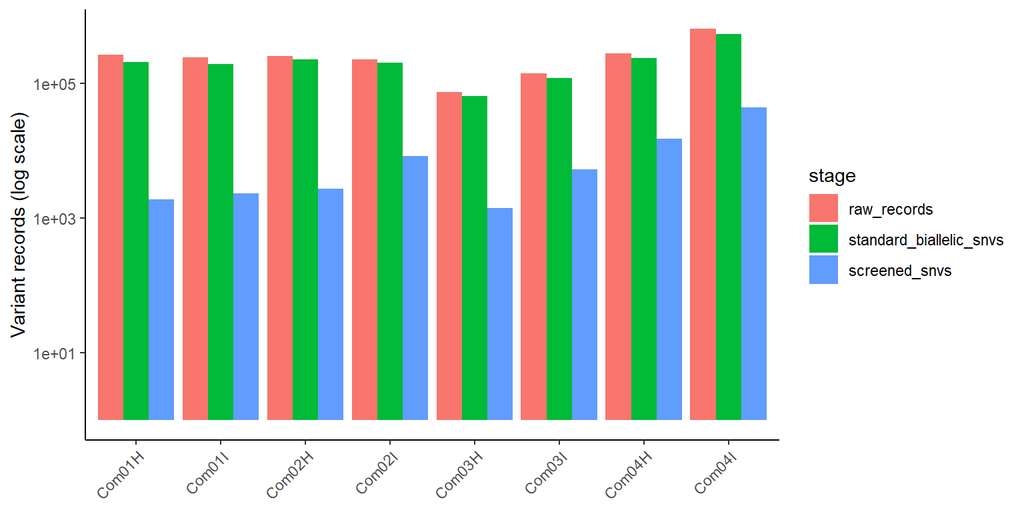

```r
# Compare the number of records retained at each filtering stage.
qc %>%
  select(sample, raw_records, standard_biallelic_snvs, screened_snvs) %>%
  tidyr::pivot_longer(-sample, names_to = "stage", values_to = "n") %>%
  mutate(stage = factor(
    stage,
    levels = c("raw_records", "standard_biallelic_snvs", "screened_snvs")
  )) %>%
  ggplot(aes(sample, n, fill = stage)) +
  geom_col(position = "dodge") +
  scale_y_log10() +
  labs(x = NULL, y = "Variant records (log scale)") +
  theme_classic() + theme(axis.text.x = element_text(angle = 45, hjust = 1))
```

# Limitation

The input VCFs did not include variant-level filtering status (`FILTER=.`), so the same predefined quality thresholds were applied to all samples before downstream analysis.